-- author : agailloty layout : post title : "Le suicide dans le monde de 1985 à 2016" comment : true --

# Analyse des données mondiales sur le suicide

Axel-Cleris Gailloty

16/05/2019

Selon [Intergrascol](https://www.integrascol.fr/premiere-cause-de-mortalite-en-france/), le suicide est la 5e cause de décès en France derrière le cancer, l’AVC, les accidents et l’Alzheimer. En 2012, 25 personnes se suicident par jour soit 1 personne toutes les heures. A l’échelle mondiale 1 personne se suicide toutes les 40 secondes selon [WHO Suicide](https://www.who.int/mental_health/prevention/suicide/suicideprevent/en/).  
Ces résultats ont sucité mes intérêts, j’ai donc voulu explorer à une échelle plus globale les statistiques sur le suicide. Ce projet se base entièrement sur un jeu de données de WHO Suicide portant sur les statistiques de suicide dans le monde entre 1985 et 2016.

```r
suicide <- read.csv("master.csv")
# Corriger le nom de la colonne country
colnames(suicide)[colnames(suicide) == "ï..country"] <- "country"
suicide %>% head %>% kable %>% kable_styling(bootstrap_options = c("striped", "hover", "condensed"))
```

| country | year | sex | age | suicides_no | population | suicides.100k.pop | country.year | HDI.for.year | gdp_for_year…. | gdp_per_capita…. | generation |
| --- | --- | --- | --- | --- | --- | --- | --- | --- | --- | --- | --- |
| Albania | 1987 | male | 15-24 years | 21 | 312900 | 6.71 | Albania1987 | NA | 2,156,624,900 | 796 | Generation X |
| Albania | 1987 | male | 35-54 years | 16 | 308000 | 5.19 | Albania1987 | NA | 2,156,624,900 | 796 | Silent |
| Albania | 1987 | female | 15-24 years | 14 | 289700 | 4.83 | Albania1987 | NA | 2,156,624,900 | 796 | Generation X |
| Albania | 1987 | male | 75+ years | 1 | 21800 | 4.59 | Albania1987 | NA | 2,156,624,900 | 796 | G.I. Generation |
| Albania | 1987 | male | 25-34 years | 9 | 274300 | 3.28 | Albania1987 | NA | 2,156,624,900 | 796 | Boomers |
| Albania | 1987 | female | 75+ years | 1 | 35600 | 2.81 | Albania1987 | NA | 2,156,624,900 | 796 | G.I. Generation |

# Exploration du jeu de données

Notre but ici est de comprendre de quoi est fait le jeu de données

```r
sapply(suicide, is.na) %>% colSums %>% t %>%
  kable %>% kable_styling(bootstrap_options = c("striped", "hover", "condensed"))
```

| country | year | sex | age | suicides_no | population | suicides.100k.pop | country.year | HDI.for.year | gdp_for_year…. | gdp_per_capita…. | generation |
| --- | --- | --- | --- | --- | --- | --- | --- | --- | --- | --- | --- |
| 0 | 0 | 0 | 0 | 0 | 0 | 0 | 0 | 19456 | 0 | 0 | 0 |

Seule la colonne `HDI.for.year` contient des données manquantes. Calculons cette proportion de données manquantes pour la colonne.

```r
sum(is.na(suicide$HDI.for.year))/length(suicide$HDI.for.year) * 100
```

```
## [1] 69.9353
```

Près de 70% des données de cette sont manquantes, donc pour la plupart des cas devons travailler sans cette colonne dans la suite de l’analyse. # Analyse des données ## Fréquence des variables qualitatives Essayons de comprendre davantage notre jeu de données en observant les fréquences d’apparitions des modalités de ces colonnes.  
Nous pouvons utiliser la fonction `freq` du package summarytools pour créer un tableau contenant la fréquence des variables qualitatives. Quelles sont donc les colonnes qualitatives de la base de données?

## Génération

```r
suicide %>% group_by(generation) %>%
summarize(nb = n()) %>% kable %>% kable_styling(bootstrap_options = c("striped", "hover", "condensed"))
```

| generation | nb |
| --- | --- |
| Boomers | 4990 |
| G.I. Generation | 2744 |
| Generation X | 6408 |
| Generation Z | 1470 |
| Millenials | 5844 |
| Silent | 6364 |

```r
hcbar(x = suicide$generation, name = "Génération") %>%
hc_add_theme(hc_theme_economist())
```

[interactive chart not shown]

La génération X représente 23% de la population totale des individus tandis que la génération Z qui a la faible apparition dans la base de données représente seulement 5% ## Classes d’âge

```r
hcbar(x = suicide$age, name = " ge") %>%
hc_add_theme(hc_theme_economist())
```

[interactive chart not shown]

Il semble bien que les classes d’âge sont toutes également réparties.

## Proportion de la population par sexe

```r
hcbar(x = suicide$sex, name = "Sexe") %>%
hc_add_theme(hc_theme_economist())
```

[interactive chart not shown]

Notre base de données est ce qu’on peut aller une donnée panel. Il regroupe différents pays à des années différentes, ce qui fait tous les pays n’ont pas la même proportion d’apparition. Les pays qui ont les moins d’apparition doivent être ceux pour qui les données nécessaires n’étaient pas disponibles à des dates antérieures. L’Autriche par exemple apparaît en total 382 fois, la France apparaît 360 fois mais la Mongolie n’enregistre que 10 apparitions.

## Les données sont-elles disponibles pour toutes les années?

```r
hcbar(x = as.character(suicide$year), name = "Années") %>%
hc_add_theme(hc_theme_economist())
```

[interactive chart not shown]

# Visualisation des données mondiales

```r
theme_set(theme_economist())
```

Pour commencer regardons l’évolution mondiale du taux de suicide par catégorie d’âge et par sexe.

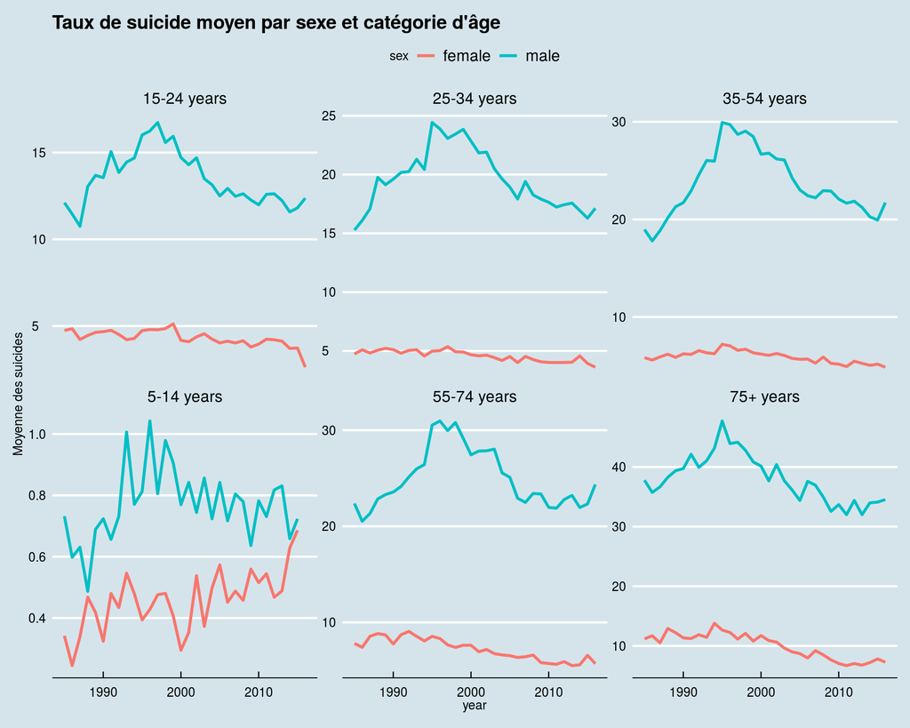

Sur ce graphique nous voyons clairement que pour toute catégorie d’âge le taux de suicide des hommes est supérieur à celui des femmes ! On observe également que l’écart des taux de suicide entre les deux sexes augmente à mesure que l’âge avance.  
Le sexe est une variable qui sépare bien la proportion de suicide.  
Testons donc la significativité des deux variables catégoriques qui nous ont servi à représenter ce graphique.

## Analyse de la variance (ANOVA)

```r
temp <- suicide %>% group_by(year,sex, age) %>%
summarize(moy_suicide = mean(suicides.100k.pop))
fit <- aov(formula = moy_suicide~age+sex, data = temp)
summary(fit)
```

```
##              Df Sum Sq Mean Sq F value Pr(>F)
## age           5  19222    3844   171.4 <2e-16 ***
## sex           1  20754   20754   925.1 <2e-16 ***
## Residuals   375   8413      22
## ---
## Signif. codes:  0 '***' 0.001 '**' 0.01 '*' 0.05 '.' 0.1 ' ' 1
```

Il existe une différence statistiquement significative entre le taux de suicide des hommes et des femmes ainsi que selon la catégorie d’âge. ## Corrélation entre les variables quantitatives

```r
library(ggcorrplot)
```

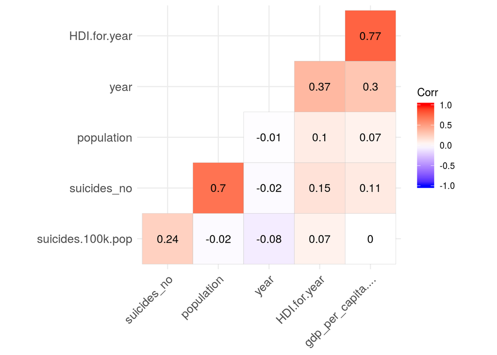

```r
options(repr.plot.height = 4, repr.plot.res = 180, repr.plot.width = 6)
suicide[,sapply(suicide, is.numeric)] %>%
cor(use = "complete.obs") %>% ggcorrplot(hc.order = TRUE, type = "lower",
   lab = TRUE)
```

Pour que nous puissons bien utiliser cette variable, nous allons diviser le PIB par catégorie d’âge, comme ça nous pouvons facilement les sommer lorsque nous groupons les données.

```r
suicide$gdp <- gsub(",","",suicide$gdp_for_year....) %>% as.numeric()
gdp <- suicide %>% group_by(country, year) %>%
summarize(occurence = n(), gdp = sum(gdp)) %>% mutate(real_gdp = gdp/occurence)
```

```r
france <- gdp %>% filter(country == "France")
germany <- gdp %>% filter(country == "Germany")
canada <- gdp %>% filter(country == "Canada")
```

[interactive chart not shown]

```r
gdp_2014 <- suicide %>% group_by(country, year) %>%
summarize(occurence = n(), gdp = sum(gdp)) %>% mutate(real_gdp = gdp/occurence) %>%
filter(year == 2014)
```

[interactive chart not shown]

Le jeu de donnée manque les données de la Chine, ce qui fait que le Japon se place en deuxième position en termes de PIB.

Voyons maintenant le PIB par tête.

[interactive chart not shown]

```r
suicide_2010 <- suicide %>% group_by(country, year) %>%
summarize( count = n(), population = sum(population), suicide_total = sum(suicides.100k.pop)) %>%
filter(year == 2010)
```

[interactive chart not shown]

# Evolution du taux de suicide par pays

Grouper par pays, et en colonnes le taux de suicide du pays en T-n et le taux de suicide en T puis faire la différence.

```r
mixed_df <- suicide %>% group_by(country, year, sex) %>%
summarize(nb_occurence = n(), nb_suicide = sum(suicides.100k.pop)) %>% data.frame %>%
spread_(key_col = "year", value_col = "nb_suicide") %>% select(country, sex, "1986", "2014") %>% na.omit
```

```r
colnames(mixed_df) <- c("country", "sex", "yr_1986", "yr_2014")
comparison_mixed_df <- mixed_df %>%
mutate(difference = yr_2014 - yr_1986,
       pct = difference/yr_1986*100,
       variation = ifelse(difference >0, "Positive", "Négative"))
```

```r
head(comparison_mixed_df) %>%
  kable() %>%
  kable_styling()
```

| country | sex | yr_1986 | yr_2014 | difference | pct | variation |
| --- | --- | --- | --- | --- | --- | --- |
| Antigua and Barbuda | female | 0.00 | 0.00 | 0.00 | NaN | Négative |
| Antigua and Barbuda | male | 0.00 | 0.00 | 0.00 | NaN | Négative |
| Argentina | female | 32.01 | 19.48 | -12.53 | -39.144017 | Négative |
| Argentina | male | 120.89 | 91.87 | -29.02 | -24.005294 | Négative |
| Australia | female | 35.38 | 34.88 | -0.50 | -1.413228 | Négative |
| Australia | male | 140.41 | 114.19 | -26.22 | -18.673884 | Négative |

## Représentons maintenant cette différence

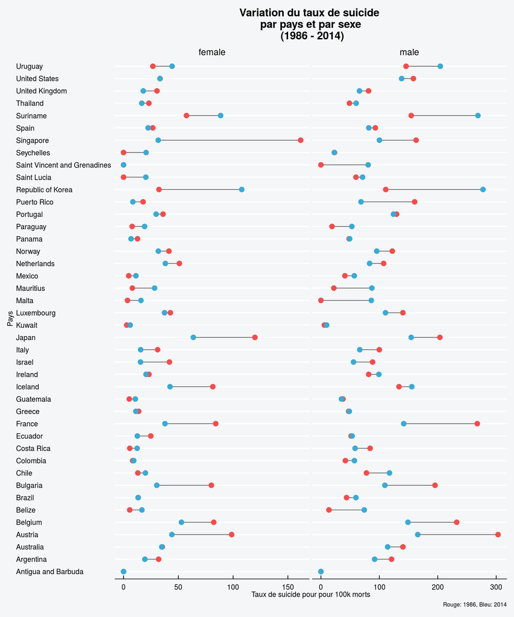

# Analyse multidimensionnelle

Notre but est de rassembler les pays sur un graphique qui nous indique la population du pays, son taux de suicide et sa richesse par tête.  
Nous allons faire cette analyse sur deux périodes suffisamment éloignée pour observer comment les choses ont changé.

## En 1986

```r
pca_data <- suicide %>% group_by(country, year) %>%
summarize(nb_occurence = n(), sum_gdp = sum(gdp),
          population = sum(population), suicide = sum(suicides.100k.pop),
          gdp_real = sum_gdp/nb_occurence, gdp_per_capita = gdp_real/population)
pca_1986 <- pca_data %>% filter(year == 1986) %>% select(country, population, suicide, gdp_per_capita) %>%
data.frame(row.names = "country")
```

```r
library(FactoMineR)
```

```r
library(factoextra)
```

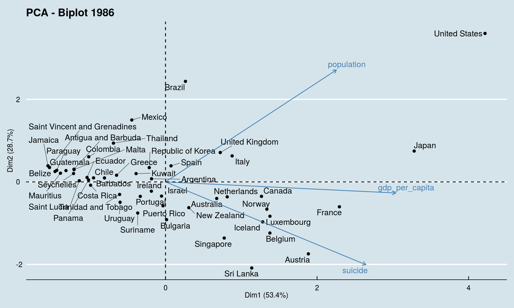

La première dimension explique 53% de la variabilité entre les pays. Elle est positivement influencée par les 3 variables, mais le PIB par tête domine les autres. La deuxième dimension quant à elle explique 29% de l’information et elle est fortement influencée positivement par la population et négativement par le suicide.  
Ces deux axes nous permettent de dire que un pays dont les coordonnées sont situées à droite de ce graphique est un pays riche et un pays situés en haut est un pays peuplé. Plus un bas se situe en bas plus sa proportion de suicide est élevée. ## En 2015 Voyons comment la situation des pays a changé en 29 ans

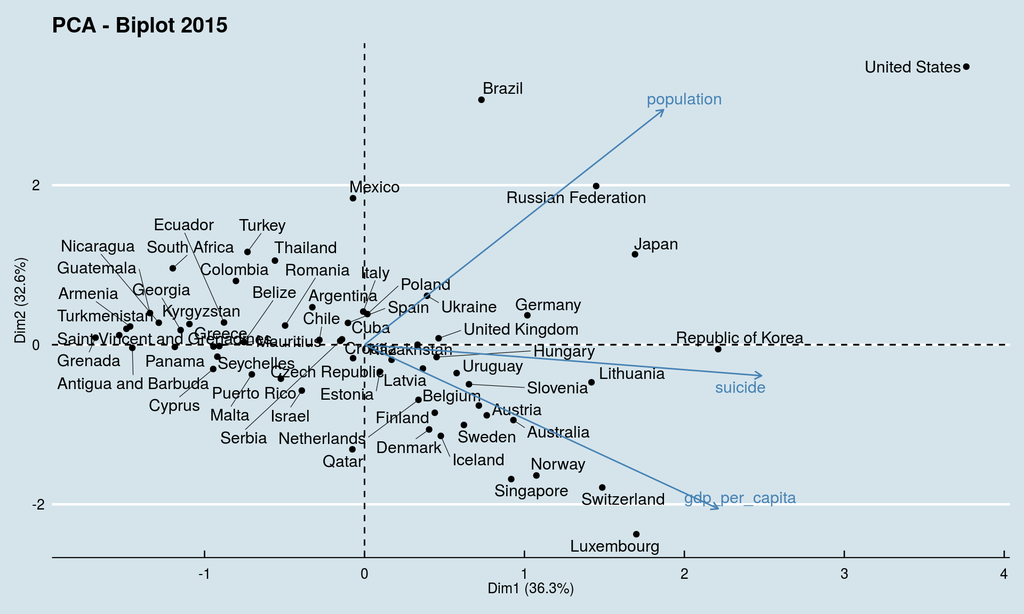

Comparé aux résultats obtenus en 1986, les deux dimensions ont à peu près les mêmes importances. Le suicide n’est plus aussi important qu’il ne l’était en 1986. La direcion des flèches a changé : plus un pays se trouve à droite plus son taux de suicide est élevé. Les pays qui se trouvent en haut et à droite sont des pays qui ont une forte population et un fort taux de suicide. Tandis que les pays qui se trouvent en bas ont une faible population mais un PIB par habitant très élevé. # Lien entre la richesse et le suicide

[interactive chart not shown]

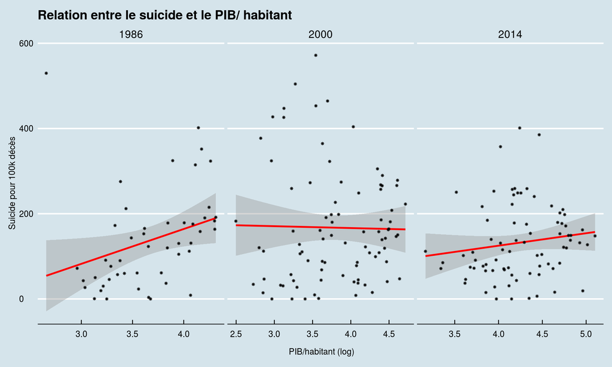

```r
data <- suicide %>% group_by(country, year) %>%
summarize(nb = n(), pop = sum(population), suicide_100k = sum(suicides.100k.pop),
         gdp = sum(gdp), real_gdp = gdp/nb, gdp_per_capita = real_gdp/pop)
highchart() %>% hc_title(text = "Lien entre le PIB et le taux de suicide") %>%
  hc_add_series(data %>% filter(year == 1986), name = '1986', type = "scatter",
                hcaes(x = gdp_per_capita, y = suicide_100k))
```

Il y a un changement de tendance au cours du temps. En 1986 la relation entre le nombre de suicide et la richesse nationale par tête semble être positive et croissante. En 2000 cette même relation devient légèrement décroissante pour arriver à une légère hausse en 2014.  
On observe donc que la relation linéaire n’est pas clairement affirmée. Pour explorer davantage cette relation, segmentons les PIB par habitant dans des groupes pour les représenter visuellement.

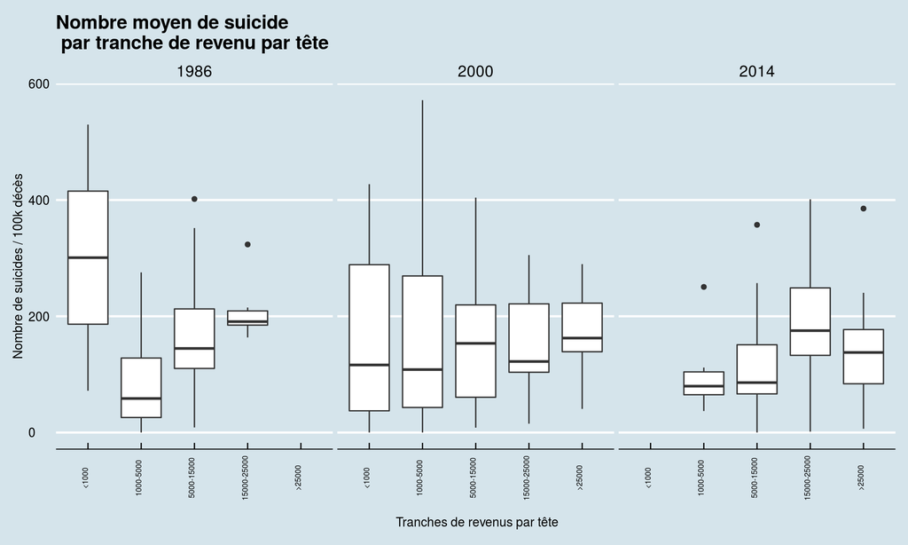

```r
comp <- data %>%
mutate(intervalle = cut(gdp_per_capita, breaks = c(0,1000,5000,15000,25000, 200000),
                       labels = c("<1000", "1000-5000", "5000-15000", "15000-25000",">25000"),
                       include.lowest = FALSE))
```

Nous devons faire attention avec l’interprétation pour deux raisons: - Pour chaque année nous n’avons pas tous les pays - Le PIB par habitant nominal augmente avec le temps: par exemple en 1986 l’Albanie avait un PIB par habitant d’environ 700 dollars alors qu’aujourd’hui elle est de [12700](http://perspective.usherbrooke.ca/bilan/tend/ALB/fr/NY.GDP.PCAP.PP.CD.html). Les résultats de 2000 sont plus justes car tous les pays présents ont pu être représentés dans chacune des tranches.